# [“Forecasting: Principles and Practice” Notes](https://www.otexts.org/fpp/1)

Francis Tan

2016-08-31

# 1 Chapter 1: Getting Started

## 1.1 Types of Quantitative Forecasts

- Cross-sectional Data
  - Given a set of parameters, try to *predict* an outcome based on data. For example, predict the house price based on number of bedrooms, bathrooms, etc.
- Time series Data
  - Forecast future outcome based on historical data

## 1.2 Basic Steps of Forecasting

1. Problem Definition
2. Gathering Information
3. Exploratory Analysis
4. Choosing and Fitting Models
5. Using and Evaluating Model

# 2 Chapter 2: Forecaster’s Toolbox

## 2.1 Graphs

First thing to do for any forecasting exercise is to plot the data to look for patterns or any abnormalities.

### 2.1.1 Time Plots

aka Line graphs.

#### 2.1.1.1 Example 1

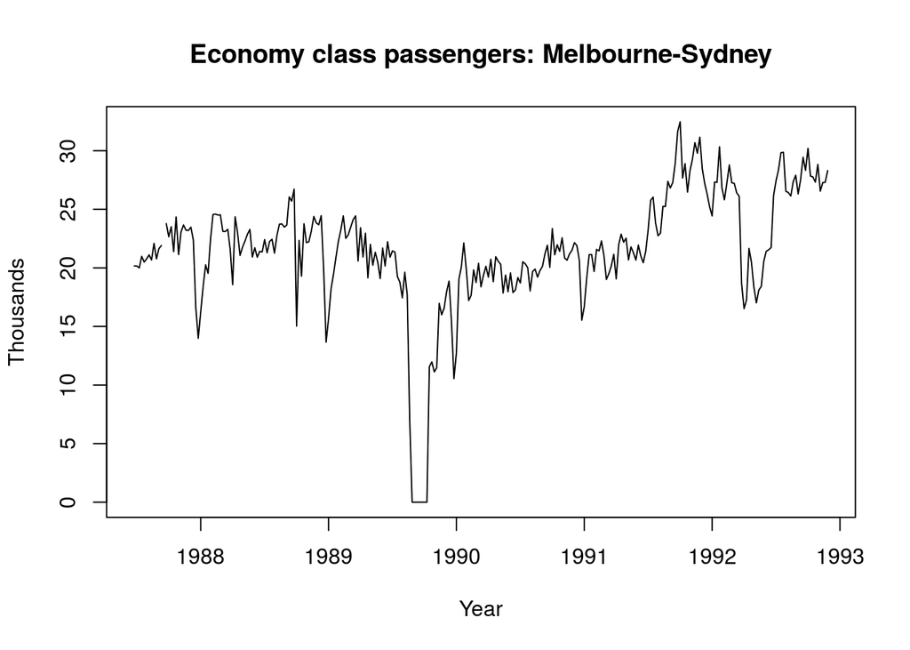

```r
data(melsyd)
plot(melsyd[,"Economy.Class"],
  main="Economy class passengers: Melbourne-Sydney",
  xlab="Year",ylab="Thousands")
```

Notes:

- Missing data in 1989 – industrial dispute
- Dip in 1992 – trial which replaced some economy class seats with business class
- Large increase in 1991
- etc

#### 2.1.1.2 Example 2

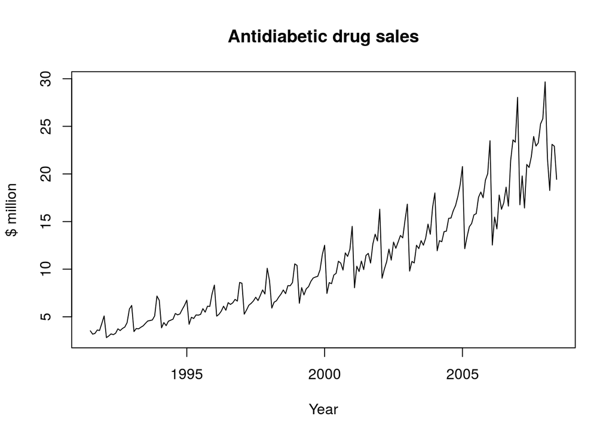

```r
data(a10)
plot(a10, ylab="$ million", xlab="Year", main="Antidiabetic drug sales")
```

Notes:

- Seasonality
- Upward trend

#### 2.1.1.3 Common Time Series Patterns

- **Trend**
- **Seasonality**
- **Cycles** – rises and falls that are not of a fixed period

### 2.1.2 Seasonal Plots

Line plots comparing each *season*.

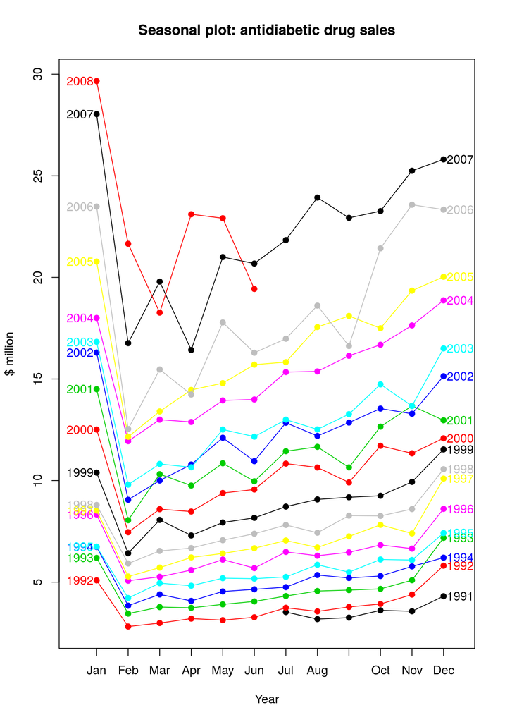

```r
seasonplot(a10,
           ylab='$ million',
           xlab='Year',
           main='Seasonal plot: antidiabetic drug sales',
           year.labels=TRUE,
           year.labels.left=TRUE,
           col=1:20,
           pch=19)
```

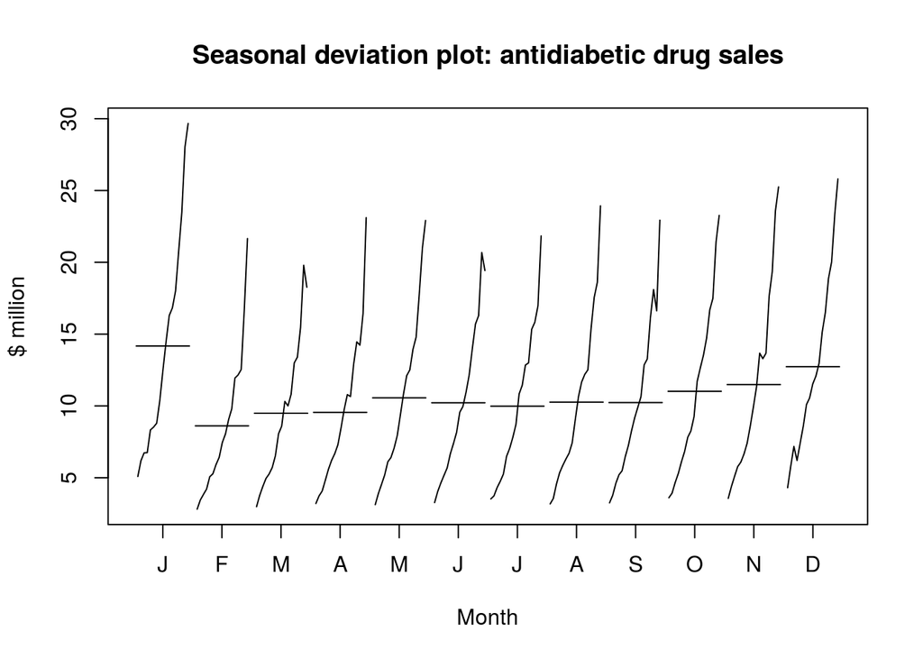

```r
monthplot(a10,
          ylab='$ million',
          xlab='Month',
          main='Seasonal deviation plot: antidiabetic drug sales')
```

### 2.1.3 Scatterplots

Useful for analyzing cross-sectional data

## 2.2 Summary Statistics

### 2.2.1 Univariate statistics

Can simply use *summary* function on the data.

### 2.2.2 Bivariate statistics

**Correlation coefficient**: $r$
$$r = \frac{\sum{} (x_i - \overline{x})(y_i - \overline{y})}
{\sqrt{\sum{(x_i - \overline{x})^2}}\sqrt{\sum{(y_i - \overline{y})^2}}}$$

### 2.2.3 Autocorrelation

Used to test correlation on lag. $r_1$ tests correlation on lag 1, $r_2$ tests correlation on lag 2, etc.

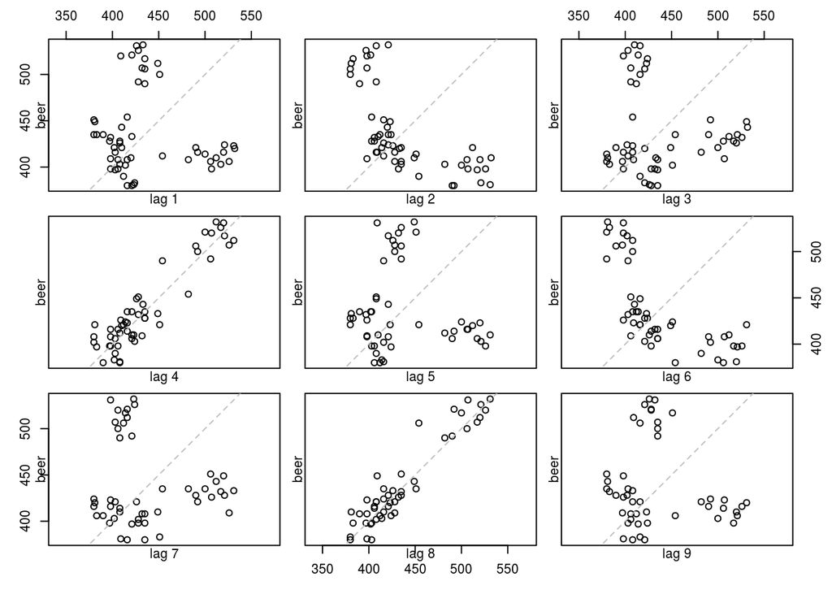

```r
data(ausbeer)
beer <- window(ausbeer, start=1992, end=2006-0.1)
lag.plot(beer, lags=9, do.lines=FALSE)
```

Each lag has a corresponding correlation value $r$. These correlation values are plotted to form an *autocorrelation function* or *ACF*. The plot is known as a *correlogram*.

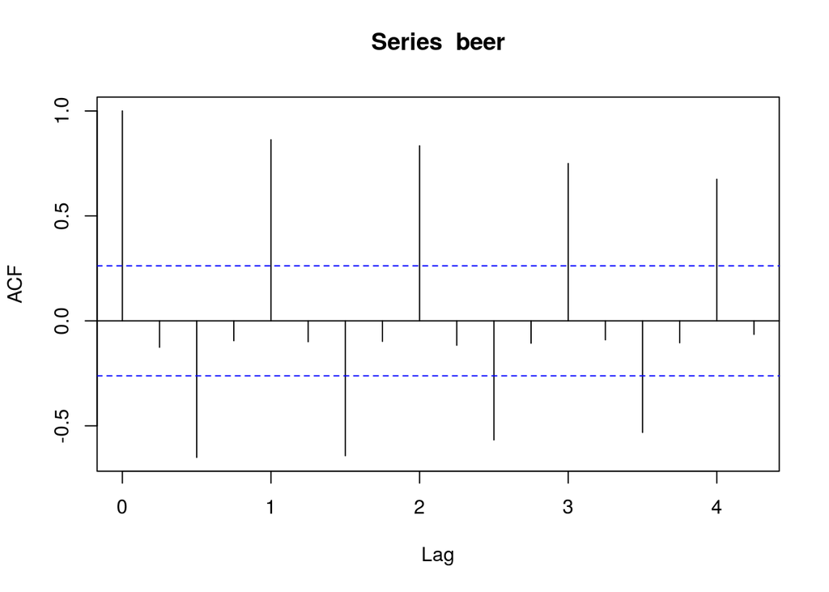

```r
acf(beer)
```

Notes:

- $r_4$ at lag 4 has the highest correlation because seasonal patterns happen every four quarters
- Negative correlations happen two quarters after peaks

Time series that show no autocorrelation are called *white noise*.Acf plot will show no significant correlations for any lag periods.

## 2.3 Simple forecasting methods

- **Mean** – just the mean of historical values for all forecasted values.
- **Naive** – just the last actual value for all forecasted values.
- **Seasonal Naive** – variation of naive. Uses the last value of some period last season.
- **Drift** – variation of naive. Allows forecast to increase or decrease over time (the *drift*) based on average change.

## 2.4 Transformations

Log and power transformations are common. *Box-Cox Transformations* is a useful family of log and power transformations. If the coefficient $\lambda$ is 0, it does a natural log, otherwise it does a power transformation. $\lambda$ can be between 0 and 1. A good lambda will transform the data such that each seasonal swing is roughly equal. Running the function *BoxCox.lambda(data)* will choose a $\lambda$ for you. In this case, it will choose $0.27$.

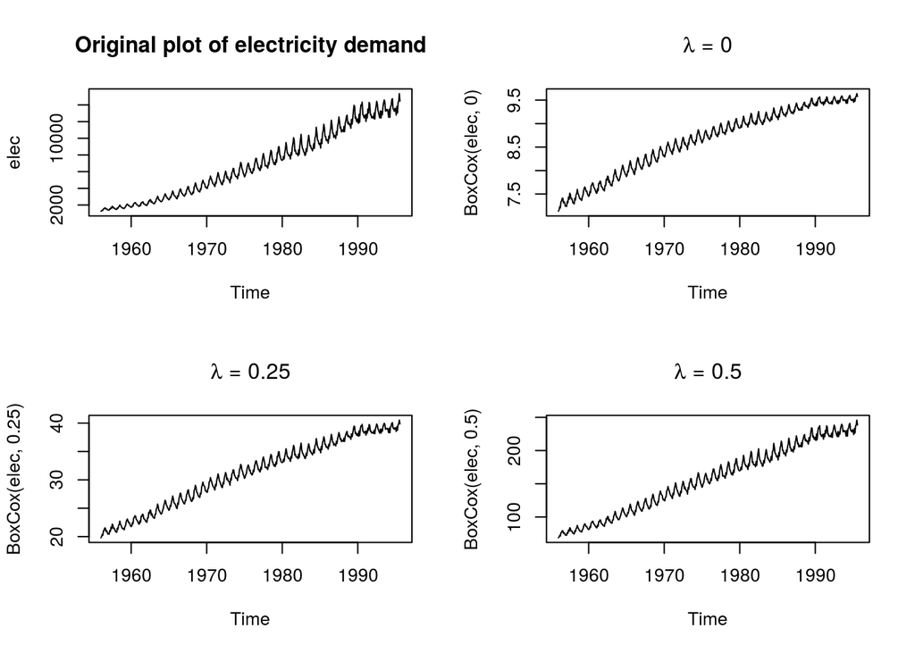

```r
data(elec)
par(mfrow=c(2, 2))
plot(elec, main='Original plot of electricity demand')
plot(BoxCox(elec, 0), main=expression(paste(lambda, ' = 0')))
plot(BoxCox(elec, 0.25), main=expression(paste(lambda, ' = 0.25')))
plot(BoxCox(elec, 0.5), main=expression(paste(lambda, ' = 0.5')))
```

After tranforming, we need to make a forecast on the transformed data. Then we need to *back transform* to obtain the forecast in the original scale.

## 2.5 Evaluating forecast accuracy

### 2.5.1 Scale-dependent errors

Forecast error is simply $e_i = y_i - \hat{y_i}$ where $y_i$ is actual and $\hat{y_i}$ is forecast. Two common measures are:

$$\text{Mean absolute error: MAE} = mean(|e_i|)$$
$$\text{Root mean squared error: RMSE} = \sqrt{mean(e_i^2)}$$

MAE is most common, however can only be compared to values on the same scale, or on the same data set.

### 2.5.2 Percentage errors

Scale independent so can compare errors from different data sets. This can be calculated as $p_i = 100e_i/y_i$. The most commonly used measure is:

$$\text{Mean absolute percentage error: MAPE} = mean(|p_i|)$$

This can present the problem is any value $y_i$ is 0 or close to 0.

### 2.5.3 Scaled errors

Scaled errors are used as an alternative to percentage errors. The *mean absolute scaled error* or *MASE* is a commonly used one (alternatively *mean squared scaled error* or *MSSE* is used).

### 2.5.4 Example

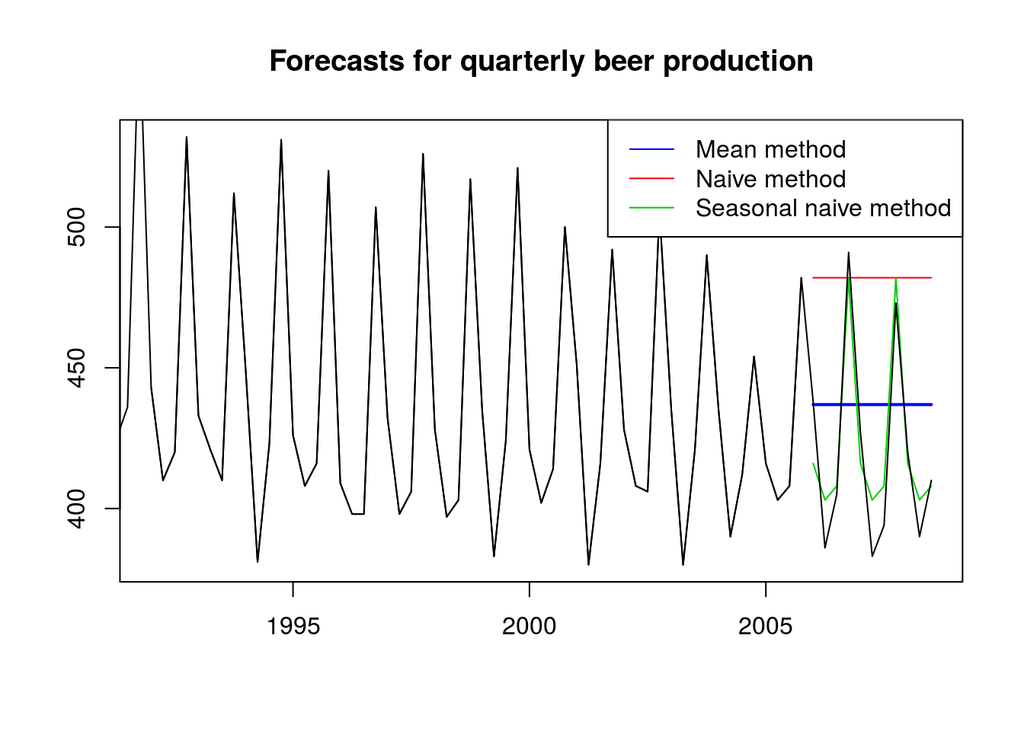

```r
beer2 <- window(ausbeer,start=1992,end=2006-.1)

beerfit1 <- meanf(beer2,h=11)
beerfit2 <- rwf(beer2,h=11)
beerfit3 <- snaive(beer2,h=11)

plot(beerfit1, plot.conf=FALSE,
  main="Forecasts for quarterly beer production")
lines(beerfit2$mean,col=2)
lines(beerfit3$mean,col=3)
lines(ausbeer)
legend("topright", lty=1, col=c(4,2,3),
  legend=c("Mean method","Naive method","Seasonal naive method"))
```

The following shows the various error tests:

```r
beer3 <- window(ausbeer, start=2006)
accuracy(beerfit1, beer3)
```

```
##                         ME     RMSE      MAE        MPE     MAPE     MASE
## Training set  8.121418e-15 44.17630 35.91135 -0.9510944 7.995509 2.444228
## Test set     -1.718344e+01 38.01454 33.77760 -4.7345524 8.169955 2.298999
##                     ACF1 Theil's U
## Training set -0.12566970        NA
## Test set     -0.08286364 0.7901651
```

```r
accuracy(beerfit2, beer3)
```

```
##                       ME     RMSE      MAE         MPE     MAPE     MASE
## Training set   0.7090909 66.60207 55.43636  -0.8987351 12.26632 3.773156
## Test set     -62.2727273 70.90647 63.90909 -15.5431822 15.87645 4.349833
##                     ACF1 Theil's U
## Training set -0.25475212        NA
## Test set     -0.08286364  1.428524
```

```r
accuracy(beerfit3, beer3)
```

```
##                     ME     RMSE      MAE        MPE     MAPE      MASE
## Training set -1.846154 17.24261 14.69231 -0.4803931 3.401224 1.0000000
## Test set     -2.545455 12.96849 11.27273 -0.7530978 2.729847 0.7672537
##                    ACF1 Theil's U
## Training set -0.3408329        NA
## Test set     -0.1786912   0.22573
```

Here we see that the seasonal naive method is best.

## 2.6 Residual diagnostics

Residuals are simply the difference between the forecast and actual value $e_i = y_i - \hat{y_i}$. A good forecast will yield residuals with the following properties:

- Residuals are uncorrelated. If you find correlations then there was something not included in the forecasting model.
- Residuals have zero mean. A non-zero mean means forecast is biased.

If the above properties are not satisfied, then forecast can be improved. If residuals have a mean $m$, then simply adding $m$ to all forecasts will solve the problem. Fixing the correlation problem will be explained in **Chapter 8**.

The following two properties are not required, but useful:

- Residuals have constant variance.
- Residuals are normally distributed.

### 2.6.1 Example: Dow Jones

Naive method is usually best for stocks. Therefore, residuals are simply the difference between consecutive observations.

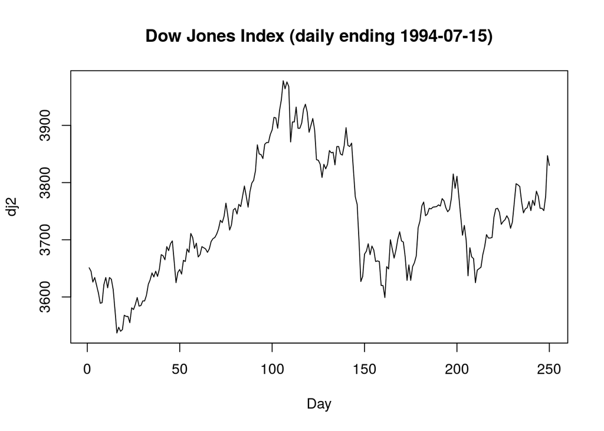

```r
data(dj)
# par(mfrow=c(4, 1))
dj2 <- window(dj, end=250)
plot(dj2,
     main='Dow Jones Index (daily ending 1994-07-15)',
     xlab='Day')
```

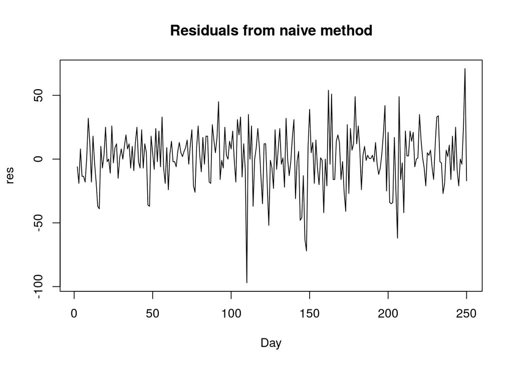

```r
res <- residuals(naive(dj2))
plot(res,
     main='Residuals from naive method',
     xlab='Day')
```

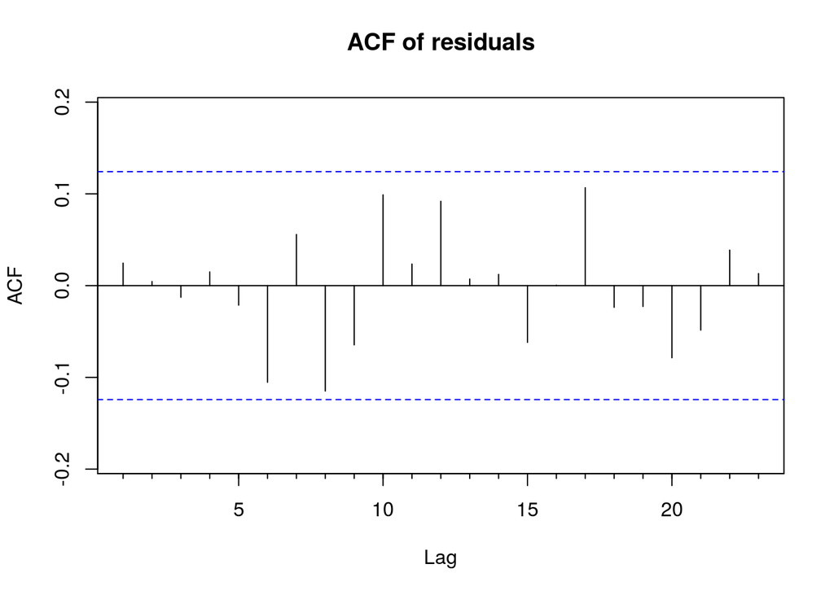

```r
Acf(res,
    main='ACF of residuals')
```

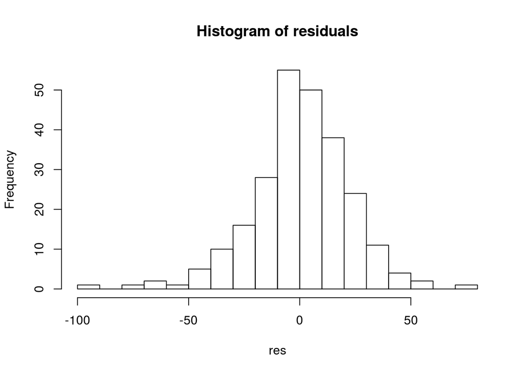

```r
hist(res,
     nclass='FD',
     main='Histogram of residuals')
```

Notes:

- [x] Residuals are not correlated.
- [x] Residuals are close to zero.
- [x] Residuals have constant variance.
- [ ] Not quite normally distributed so prediction intervals may be inaccurate.

### 2.6.2 Portmanteau tests for autocorrelation

Test if autocorrelation is the result of white noise. [Portmanteau test](https://www.otexts.org/fpp/2/6)

# 3 Chapter 4: Simple regression

Fit a line over observations where it minimizes the sum of square errors:

$$\sum_{i=1}^N{\epsilon_i^2}$$

The correlation coefficient $r$ shows how much $x$ predicts $y$.

## 3.1 Example: Car emission

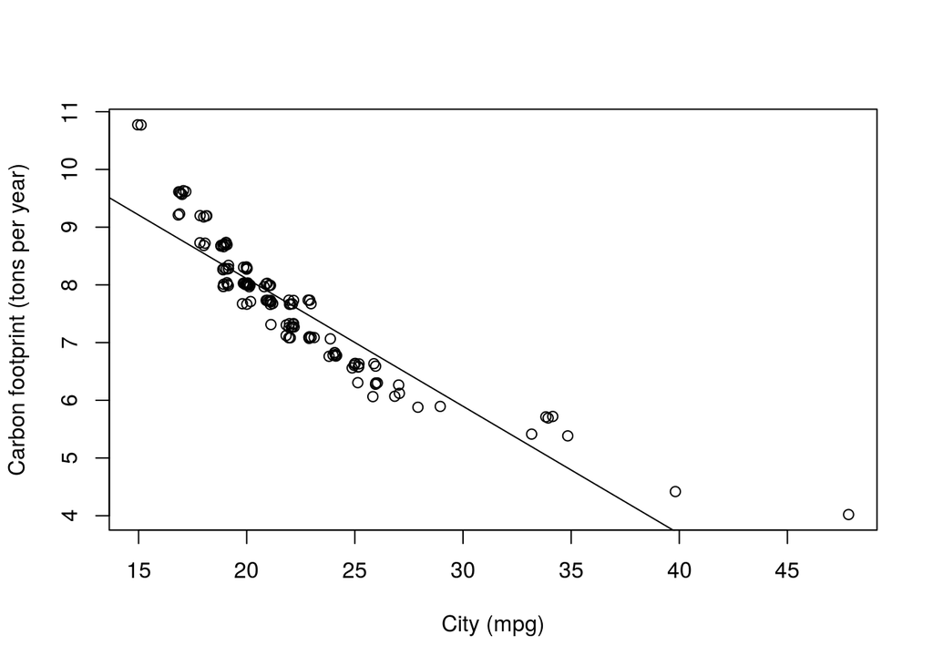

```r
data(fuel)
plot(jitter(Carbon) ~ jitter(City),
     xlab='City (mpg)',
     ylab='Carbon footprint (tons per year)',
     data=fuel)
fit <- lm(Carbon ~ City, data=fuel)
abline(fit)
```

```r
summary(fit)
```

```
##
## Call:
## lm(formula = Carbon ~ City, data = fuel)
##
## Residuals:
##     Min      1Q  Median      3Q     Max
## -0.7014 -0.3643 -0.1062  0.1938  2.0809
##
## Coefficients:
##              Estimate Std. Error t value Pr(>|t|)
## (Intercept) 12.525647   0.199232   62.87   <2e-16 ***
## City        -0.220970   0.008878  -24.89   <2e-16 ***
## ---
## Signif. codes:  0 '***' 0.001 '**' 0.01 '*' 0.05 '.' 0.1 ' ' 1
##
## Residual standard error: 0.4703 on 132 degrees of freedom
## Multiple R-squared:  0.8244, Adjusted R-squared:  0.823
## F-statistic: 619.5 on 1 and 132 DF,  p-value: < 2.2e-16
```

## 3.2 Evaluating regression models

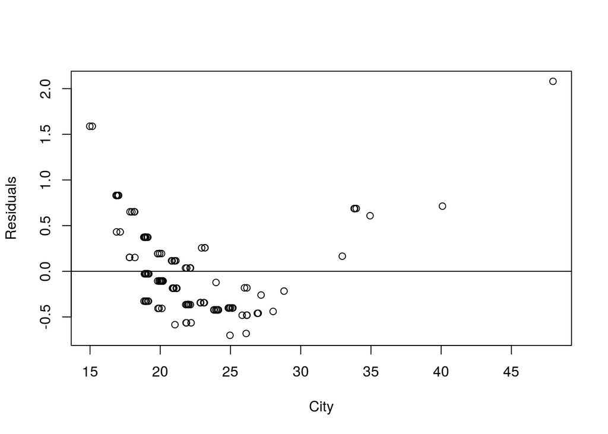

```r
res <- residuals(fit)
plot(jitter(res) ~ jitter(City),
     ylab='Residuals',
     xlab='City',
     data=fuel)
abline(0, 0)
```

We see that there is a U-shaped pattern and therefore a simple linear model may not be appropriate.

## 3.3 Outliers

An outlier is considered an *influential observation* if it has a large impact on the regression model

## 3.4 Example: Predicting weight from height

Red line is a fit if the outlier is included while the black line is the fit if outlier is excluded.

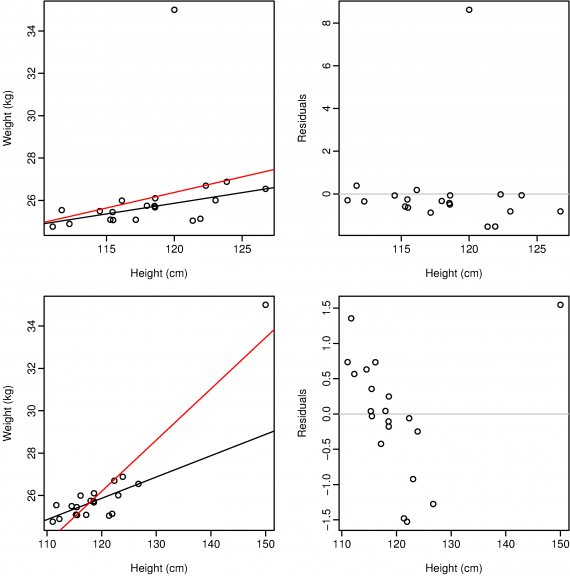

Weight vs height

## 3.5 Goodness of fit

$R^2$ or the square of the correlation coefficient $r$ measures how well the model fits the data. This can be found in the section called *Multiple R-squared* in the output of the *summary* function. The car example shows the $R^2$ value to be 0.8244. This means that 82% of the variation is captured by the model. Be careful as this is often used incorrectly. As in the example above, we see that the residuals have a U-shaped pattern.

## 3.6 Standard error of regression

Another measure of how well a model fits is the *Standard error of regression* which is the same as the standard deviation of residuals. This can be found in the section called *Residual standard error* in the output of the *summary* function. This is also used in calculating the prediction interval.

## 3.7 Non-linear regression

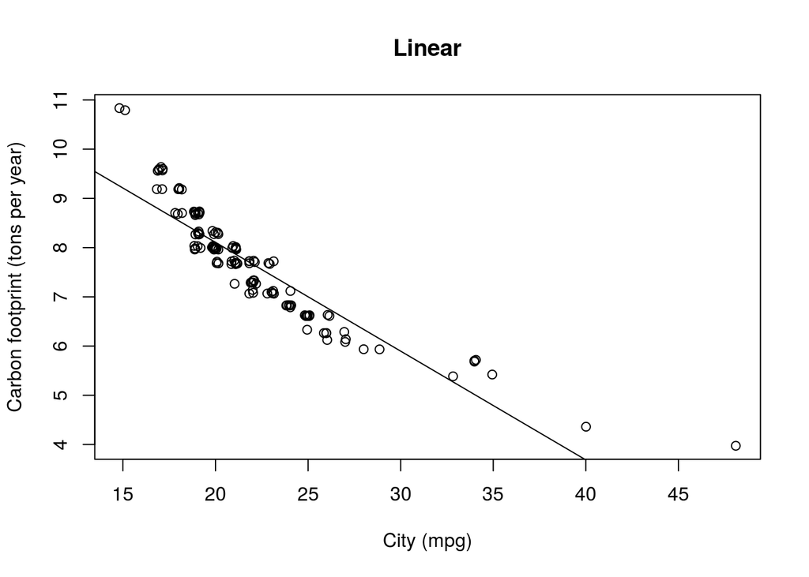

```r
fit <- lm(Carbon ~ City, data=fuel)
fit2 <- lm(log(Carbon) ~ log(City), data=fuel)
fit3 <- lm(Carbon ~ log(City), data=fuel)
fit4 <- lm(log(Carbon) ~ City, data=fuel)
plot(jitter(Carbon) ~ jitter(City),
     xlab='City (mpg)',
     ylab='Carbon footprint (tons per year)',
     main='Linear',
     data=fuel)
lines(1:50, fit$coef[1] + fit$coef[2] * (1:50))
```

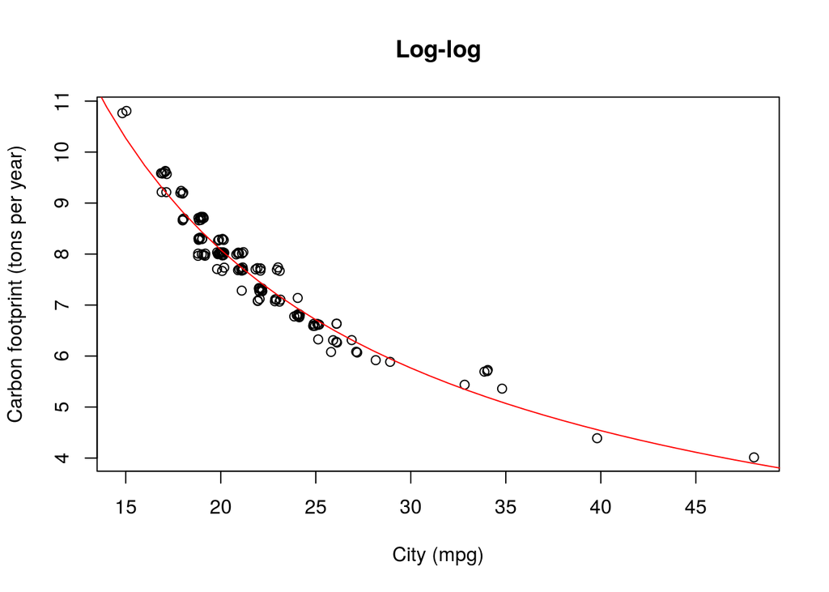

```r
plot(jitter(Carbon) ~ jitter(City),
     xlab='City (mpg)',
     ylab='Carbon footprint (tons per year)',
     main='Log-log',
     data=fuel)
lines(1:50, exp(fit2$coef[1] + fit2$coef[2] * log(1:50)), col='red')
```

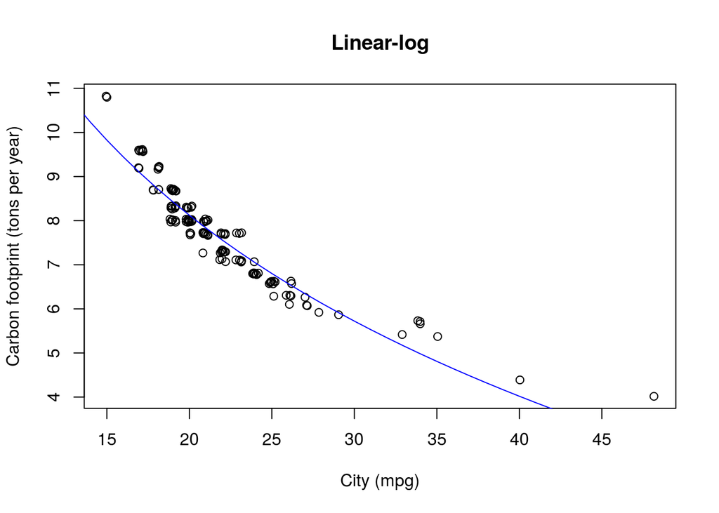

```r
plot(jitter(Carbon) ~ jitter(City),
     xlab='City (mpg)',
     ylab='Carbon footprint (tons per year)',
     main='Linear-log',
     data=fuel)
lines(1:50, fit3$coef[1] + fit3$coef[2] * log(1:50), col='blue')
```

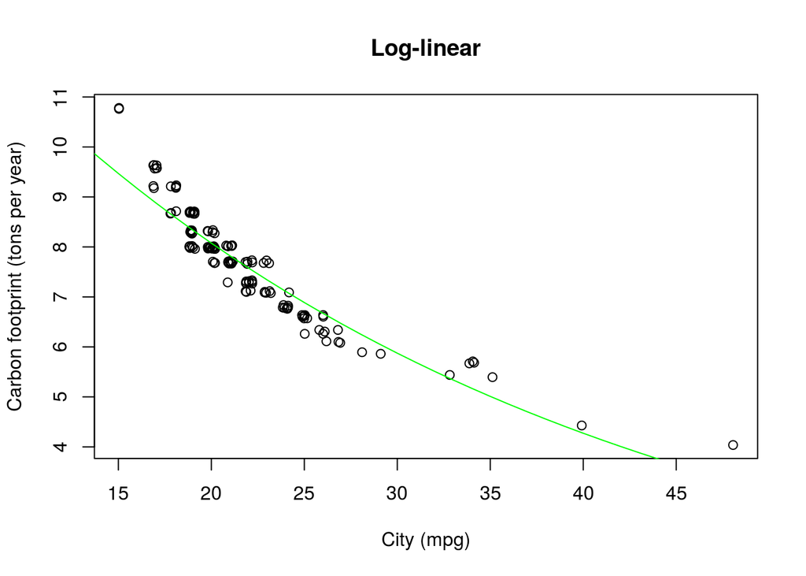

[output not shown]

```r
plot(jitter(Carbon) ~ jitter(City),
     xlab='City (mpg)',
     ylab='Carbon footprint (tons per year)',
     main='Log-linear',
     data=fuel)
lines(1:50, exp(fit4$coef[1] + fit4$coef[2] * (1:50)), col='green')
```

# 4 Chapter 8: ARIMA

## 4.1 Stationarity and differencing

Needs to be stationary so need to difference first. Differencing can be one of two type:

1. First order (or second) differencing.
2. Seasonal differencing.

When to difference can be somewhat subjective

### 4.1.1 Unit root tests

One way to see if differencing is require is to use a *unit root test*. These are basically unit tests. One popular one is *Augmented Dickey-Fuller (ADF) test*.

```r
adf.test(x, alternative='stationary')
```

Null hypothesis is that the data is not stationary. So large p-value (using 5% threshold, larger than 0.05 is large) indicates that differencing is required.

A useful R function is `ndiffs()` to find out how many times the data needs to be differenced and `nsdiffs()` to find out how many times it needs seasonal differencing.

Example:

```r
ns <- nsdiffs(x)
if(ns > 0) {
  xstar <- diff(x,lag=frequency(x),differences=ns)
} else {
  xstar <- x
}
nd <- ndiffs(xstar)
if(nd > 0) {
  xstar <- diff(xstar,differences=nd)
}
```

## 4.2 Non-seasonal ARIMA models

```r
fit <- auto.arima(usconsumption[,1],seasonal=FALSE)
fit
```

```
## Series: usconsumption[, 1]
## ARIMA(0,0,3) with non-zero mean
##
## Coefficients:
##          ma1     ma2     ma3  intercept
##       0.2542  0.2260  0.2695     0.7562
## s.e.  0.0767  0.0779  0.0692     0.0844
##
## sigma^2 estimated as 0.3953:  log likelihood=-154.73
## AIC=319.46   AICc=319.84   BIC=334.96
```

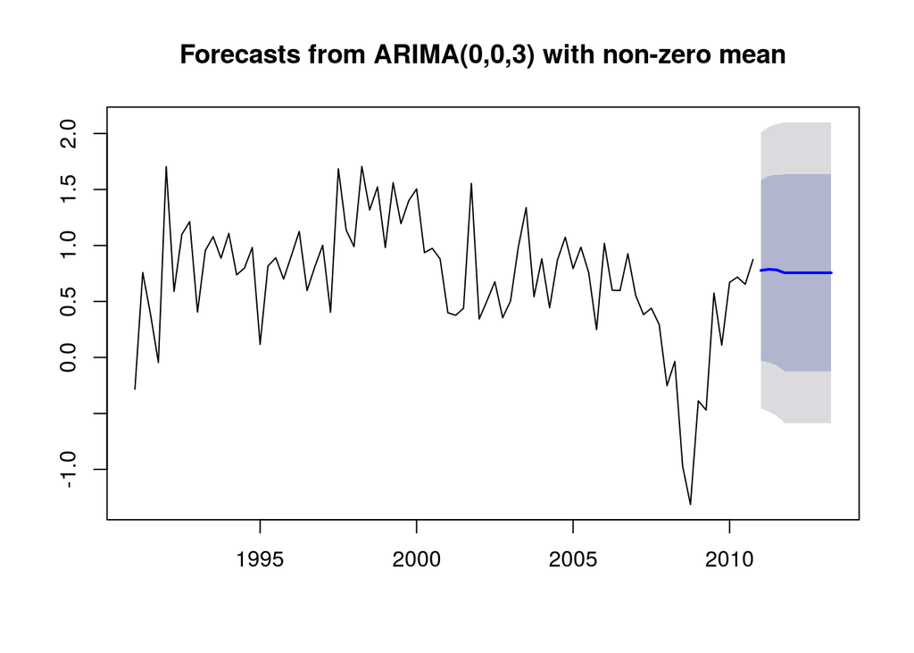

```r
plot(forecast(fit,h=10),include=80)
```

## 4.3 Auto ARIMA

The *auto.arima()* function can be useful but also dangerous. Be wary of the following:

- If c=0 and d=0, long-term forecasts will go to zero.
- If c=0 and d=1, will go to non-zero constant.
- If c=0 and d=2, will follow straight line.
- If c!=0 and d=0, will go to mean of data.
- If c!=0 and d=1, will follow a straight line.
- If c!=0 and d=2, will follow quadratic trend.

## 4.4 ACF and PACF

The ACF and PACF graphs may be helpful in finding the $p$ and $q$ values. If data are from a *ARIMA(p, d, 0)* or *ARIMA(0, d, q)*, then the ACF or PACF can be useful.

If the data follows *ARIMA(p, d, 0)* then the ACF and PACF plots of the differenced data will have the following patterns:

- the ACF is exponentially decaying or sinusoidal;
- there is a significant spike at lag $p$ in PACF but not beyond that

if the data follows *ARIMA(0, d, q)* then the ACF and PACF plots of the differenced data will have the following patterns:

- the PACF is exponentially decaying or sinusoidal;
- there is a significant spike at lag $q$ in ACF but not beyond that

## 4.5 ARIMA example (manual method)

Process:

1. Plot data and identify unusual observations and patterns.
2. If necessary, use Box-Cox transformation to stabilize variance.
3. Difference the data until stationary. Use unit root test.
4. Plot ACF/PACF of differenced data to find order.
5. Try your model along with variations. Minimize the AICc.
6. Check residuals by plotting the ACF of residuals and conducting a portmanteau test.
7. If residuals look like white noise, then forecast using model.

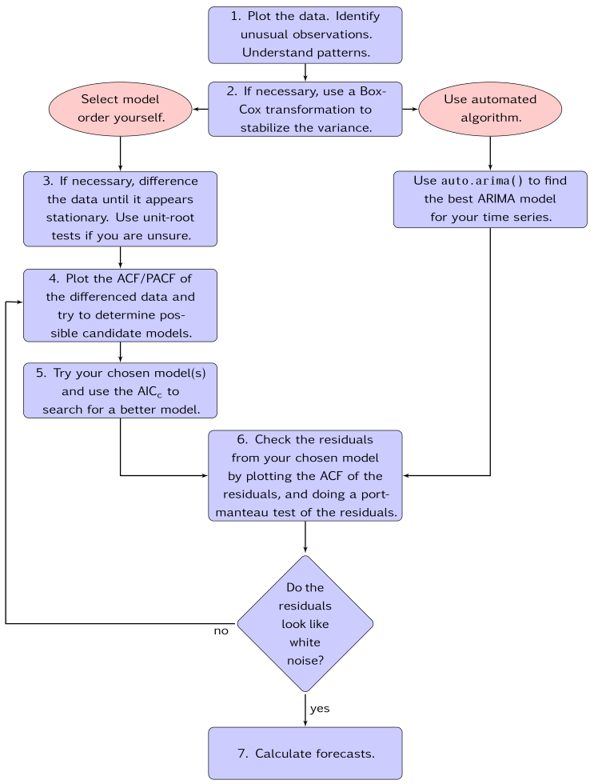

### 4.5.1 Step 1: Plot data

Here is what the original data looks like.

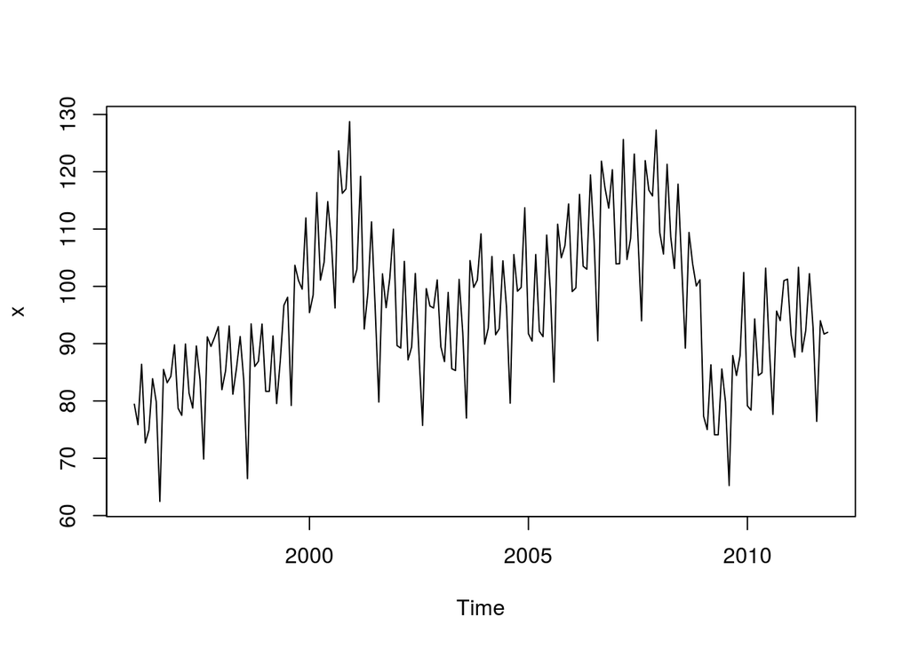

```r
data(elecequip)
x <- elecequip
plot(x)
```

### 4.5.2 Step 2: Box-Cox transformation

Variance looks stable so no need for a Box-Cox transformation.

### 4.5.3 Step 3: Differencing

We’ll use unit root tests to see if we need to difference.

```r
nsdiffs(x)
```

```
## [1] 1
```

Function states we need to seasonaly difference once.

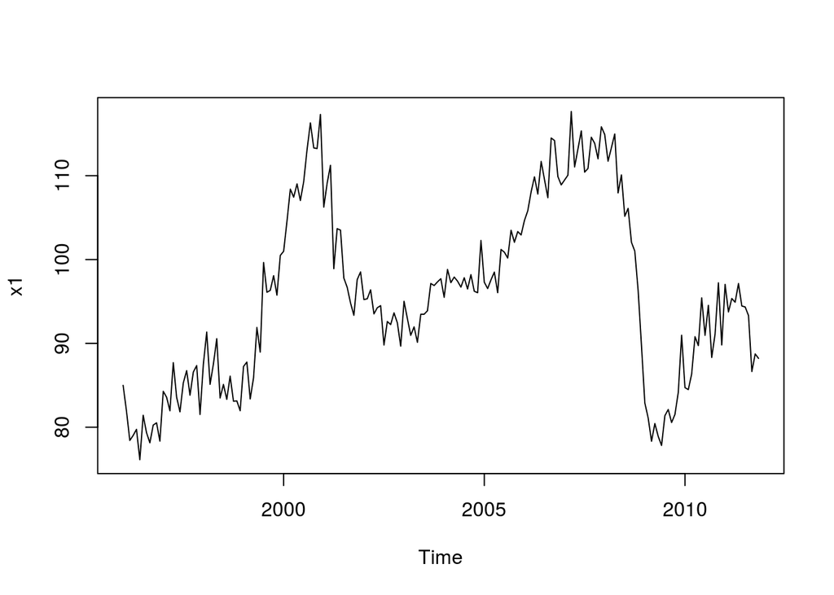

```r
m <- frequency(x)
x1 <- seasadj(stl(x, s.window='periodic'))
plot(x1)
```

Still not stationary. Let’s run a first order difference.

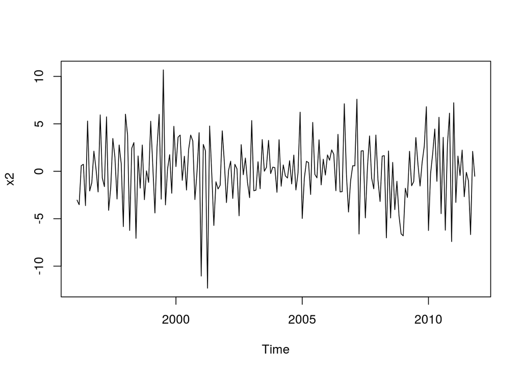

```r
x2 <- diff(x1)
plot(x2)
```

Better. Final check using unit root test.

```r
nsdiffs(x2)
```

```
## [1] 0
```

```r
ndiffs(x2)
```

```
## [1] 0
```

### 4.5.4 Step 4: ACF/PACF

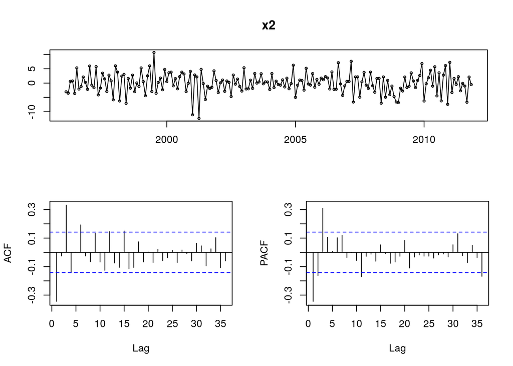

```r
tsdisplay(x2)
```

ACF is sinusoidal. PACF shows spike up to lag 3. Potential order of c(3, 1, 0). Let’s try that along with other variations such as:

- c(4, 1, 0)
- c(2, 1, 0)
- c(3, 1, 1)
- c(4, 1, 1)
- c(2, 1, 1)

### 4.5.5 Step 5: Minimize AICc

```r
summary(Arima(x1, order=c(3, 1, 0)))
```

```
## Series: x1
## ARIMA(3,1,0)
##
## Coefficients:
##           ar1      ar2     ar3
##       -0.3488  -0.0386  0.3139
## s.e.   0.0690   0.0736  0.0694
##
## sigma^2 estimated as 9.853:  log likelihood=-485.67
## AIC=979.33   AICc=979.55   BIC=992.32
##
## Training set error measures:
##                      ME     RMSE      MAE         MPE     MAPE      MASE
## Training set 0.01170679 3.105828 2.430723 -0.04353974 2.560168 0.2964478
##                     ACF1
## Training set -0.03463506
```

```r
summary(Arima(x1, order=c(4, 1, 0)))
```

```
## Series: x1
## ARIMA(4,1,0)
##
## Coefficients:
##           ar1      ar2     ar3     ar4
##       -0.3847  -0.0341  0.3551  0.1138
## s.e.   0.0723   0.0731  0.0737  0.0728
##
## sigma^2 estimated as 9.777:  log likelihood=-484.45
## AIC=978.9   AICc=979.23   BIC=995.14
##
## Training set error measures:
##                       ME     RMSE      MAE         MPE     MAPE      MASE
## Training set 0.005571975 3.085604 2.401538 -0.04310566 2.528205 0.2928884
##                       ACF1
## Training set -0.0002297178
```

```r
summary(Arima(x1, order=c(2, 1, 0)))
```

```
## Series: x1
## ARIMA(2,1,0)
##
## Coefficients:
##           ar1      ar2
##       -0.4019  -0.1660
## s.e.   0.0717   0.0717
##
## sigma^2 estimated as 10.87:  log likelihood=-495.34
## AIC=996.68   AICc=996.81   BIC=1006.42
##
## Training set error measures:
##                      ME     RMSE      MAE         MPE     MAPE      MASE
## Training set 0.02904185 3.270719 2.472795 -0.04743905 2.610552 0.3015789
##                    ACF1
## Training set 0.05216481
```

```r
summary(Arima(x1, order=c(3, 1, 1)))
```

```
## Series: x1
## ARIMA(3,1,1)
##
## Coefficients:
##          ar1     ar2     ar3      ma1
##       0.0519  0.1191  0.3730  -0.4542
## s.e.  0.1840  0.0888  0.0679   0.1993
##
## sigma^2 estimated as 9.737:  log likelihood=-484.08
## AIC=978.17   AICc=978.49   BIC=994.4
##
## Training set error measures:
##                        ME     RMSE      MAE         MPE     MAPE      MASE
## Training set -0.001227744 3.079373 2.389267 -0.04290849 2.517748 0.2913919
##                     ACF1
## Training set 0.008928479
```

```r
summary(Arima(x1, order=c(4, 1, 1)))
```

```
## Series: x1
## ARIMA(4,1,1)
##
## Coefficients:
##          ar1     ar2     ar3      ar4      ma1
##       0.1805  0.1626  0.3761  -0.0657  -0.5752
## s.e.  0.2360  0.1015  0.0687   0.1155   0.2224
##
## sigma^2 estimated as 9.775:  log likelihood=-483.93
## AIC=979.87   AICc=980.33   BIC=999.35
##
## Training set error measures:
##                        ME     RMSE     MAE         MPE     MAPE     MASE
## Training set -0.001948234 3.076947 2.39058 -0.04216591 2.519967 0.291552
##                      ACF1
## Training set 0.0004688917
```

```r
summary(Arima(x1, order=c(2, 1, 1)))
```

```
## Series: x1
## ARIMA(2,1,1)
##
## Coefficients:
##           ar1      ar2     ma1
##       -0.9015  -0.3842  0.5147
## s.e.   0.1544   0.0726  0.1573
##
## sigma^2 estimated as 10.52:  log likelihood=-491.76
## AIC=991.52   AICc=991.74   BIC=1004.51
##
## Training set error measures:
##                      ME     RMSE      MAE         MPE     MAPE      MASE
## Training set 0.02630035 3.208853 2.445192 -0.04627073 2.580595 0.2982124
##                    ACF1
## Training set 0.04285319
```

Looks like order (3, 1, 1) has the smallest AICc of 978.49.

```r
fit <- Arima(x1, order=c(3, 1, 1))
```

### 4.5.6 Step 6: Check residuals

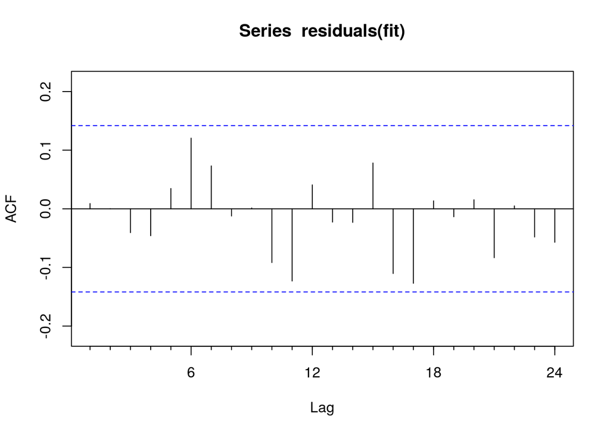

```r
Acf(residuals(fit))
```

ACF looks good. Let’s try the Portmanteau test.

```r
Box.test(residuals(fit), lag=24, fitdf=4, type='Ljung')
```

```
##
##  Box-Ljung test
##
## data:  residuals(fit)
## X-squared = 20.496, df = 20, p-value = 0.4273
```

p-value is large so just white noise.

Recommended lag is 10 for non-seasonal data and $2m$ for seasonal where $m$ is a period of seasonality. This can’t be too large, so if larger than $T/5$ where $T$ is the number of observations, the just use $T/5$.

`fitdf` is just the sum of $p$ and $q$.

### 4.5.7 Step 7: Forecast

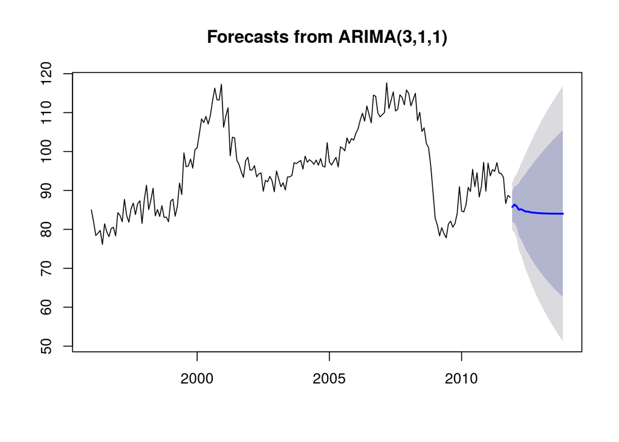

```r
plot(forecast(fit))
```

`auto.arima()` would have returned the same thing.

```r
auto.arima(x1, seasonal=FALSE)
```

```
## Series: x1
## ARIMA(3,1,1)
##
## Coefficients:
##          ar1     ar2     ar3      ma1
##       0.0519  0.1191  0.3730  -0.4542
## s.e.  0.1840  0.0888  0.0679   0.1993
##
## sigma^2 estimated as 9.737:  log likelihood=-484.08
## AIC=978.17   AICc=978.49   BIC=994.4
```